# 36_inv_func_from_graph

## 36_inv_func_from_graph

#### Question

1. A function $f$ is graphed below as $y=f(x)$.

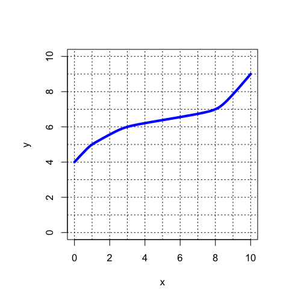

   The [inverse](https://en.wikipedia.org/wiki/Inverse_function) of the function is often denoted with a superscripted $-1$, so the inverse of $f$ is $f^{-1}$. This is an awful notation that should one day be fixed. In this context, the superscript is **NOT** an [exponentiation](https://en.wikipedia.org/wiki/Exponentiation). As stated, in this context the superscript of $-1$ implies the inverse function, which is the function that “undoes” another function.
   - Evaluate $f^{-1}(7)$.

#### Solution

#### Question

2. A function $f$ is graphed below as $y=f(x)$.

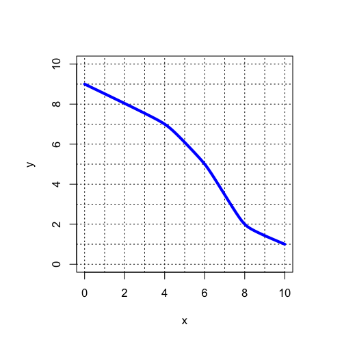

   The [inverse](https://en.wikipedia.org/wiki/Inverse_function) of the function is often denoted with a superscripted $-1$, so the inverse of $f$ is $f^{-1}$. This is an awful notation that should one day be fixed. In this context, the superscript is **NOT** an [exponentiation](https://en.wikipedia.org/wiki/Exponentiation). As stated, in this context the superscript of $-1$ implies the inverse function, which is the function that “undoes” another function.
   - Evaluate $f^{-1}(5)$.

#### Solution

#### Question

3. A function $f$ is graphed below as $y=f(x)$.

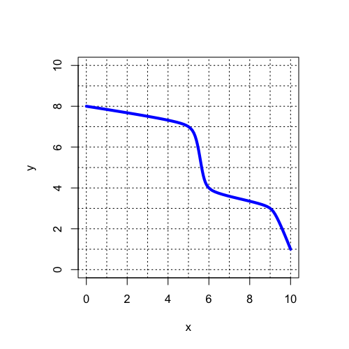

   The [inverse](https://en.wikipedia.org/wiki/Inverse_function) of the function is often denoted with a superscripted $-1$, so the inverse of $f$ is $f^{-1}$. This is an awful notation that should one day be fixed. In this context, the superscript is **NOT** an [exponentiation](https://en.wikipedia.org/wiki/Exponentiation). As stated, in this context the superscript of $-1$ implies the inverse function, which is the function that “undoes” another function.
   - Evaluate $f^{-1}(7)$.

#### Solution

#### Question

4. A function $f$ is graphed below as $y=f(x)$.

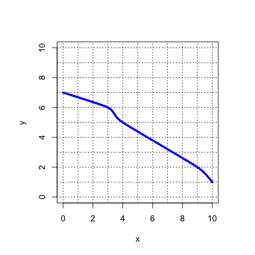

   The [inverse](https://en.wikipedia.org/wiki/Inverse_function) of the function is often denoted with a superscripted $-1$, so the inverse of $f$ is $f^{-1}$. This is an awful notation that should one day be fixed. In this context, the superscript is **NOT** an [exponentiation](https://en.wikipedia.org/wiki/Exponentiation). As stated, in this context the superscript of $-1$ implies the inverse function, which is the function that “undoes” another function.
   - Evaluate $f^{-1}(2)$.

#### Solution

#### Question

5. A function $f$ is graphed below as $y=f(x)$.

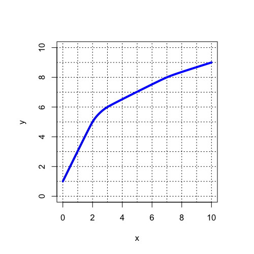

   The [inverse](https://en.wikipedia.org/wiki/Inverse_function) of the function is often denoted with a superscripted $-1$, so the inverse of $f$ is $f^{-1}$. This is an awful notation that should one day be fixed. In this context, the superscript is **NOT** an [exponentiation](https://en.wikipedia.org/wiki/Exponentiation). As stated, in this context the superscript of $-1$ implies the inverse function, which is the function that “undoes” another function.
   - Evaluate $f^{-1}(8)$.

#### Solution

#### Question

6. A function $f$ is graphed below as $y=f(x)$.

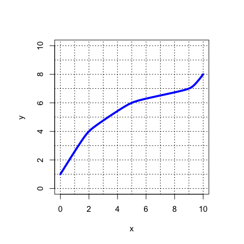

   The [inverse](https://en.wikipedia.org/wiki/Inverse_function) of the function is often denoted with a superscripted $-1$, so the inverse of $f$ is $f^{-1}$. This is an awful notation that should one day be fixed. In this context, the superscript is **NOT** an [exponentiation](https://en.wikipedia.org/wiki/Exponentiation). As stated, in this context the superscript of $-1$ implies the inverse function, which is the function that “undoes” another function.
   - Evaluate $f^{-1}(7)$.

#### Solution

#### Question

7. A function $f$ is graphed below as $y=f(x)$.

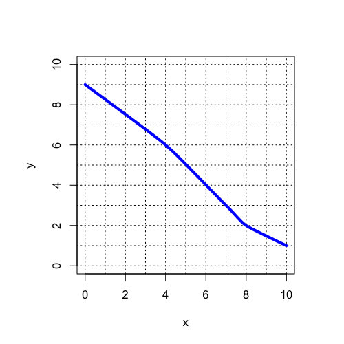

   The [inverse](https://en.wikipedia.org/wiki/Inverse_function) of the function is often denoted with a superscripted $-1$, so the inverse of $f$ is $f^{-1}$. This is an awful notation that should one day be fixed. In this context, the superscript is **NOT** an [exponentiation](https://en.wikipedia.org/wiki/Exponentiation). As stated, in this context the superscript of $-1$ implies the inverse function, which is the function that “undoes” another function.
   - Evaluate $f^{-1}(3)$.

#### Solution

#### Question

8. A function $f$ is graphed below as $y=f(x)$.

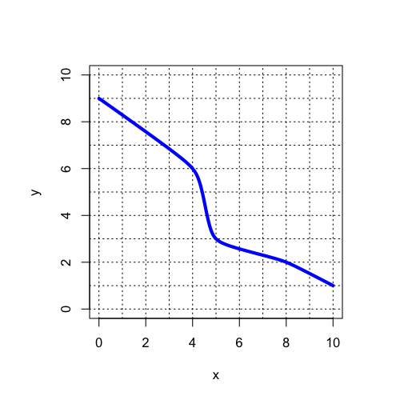

   The [inverse](https://en.wikipedia.org/wiki/Inverse_function) of the function is often denoted with a superscripted $-1$, so the inverse of $f$ is $f^{-1}$. This is an awful notation that should one day be fixed. In this context, the superscript is **NOT** an [exponentiation](https://en.wikipedia.org/wiki/Exponentiation). As stated, in this context the superscript of $-1$ implies the inverse function, which is the function that “undoes” another function.
   - Evaluate $f^{-1}(2)$.

#### Solution